# Predicting Quality of Barbell Exercises from Accelerometer Data

This project examines data from wearable devices on the belt, forearm, arm, and dumbbell of participants while they lift barbells. Some of the lifts are done correctly and some incorrectly, and the goal of the project is to classify lifts according to a grading scale from A to E.

## Exploratory Data Analysis

The first step is to read the training and testing data sets, which can be done with the following R commands.

```r
alltraining <- read.csv("pml-training.csv", header=TRUE)
testing <- read.csv("pml-testing.csv", header=TRUE)
```

At this point, it’s important to see the data to try to understand what is available. We can summarize the data as follows.

```r
summary(alltraining)
```

```
##        X            user_name    raw_timestamp_part_1 raw_timestamp_part_2
##  Min.   :    1   adelmo  :3892   Min.   :1.322e+09    Min.   :   294
##  1st Qu.: 4906   carlitos:3112   1st Qu.:1.323e+09    1st Qu.:252912
##  Median : 9812   charles :3536   Median :1.323e+09    Median :496380
##  Mean   : 9812   eurico  :3070   Mean   :1.323e+09    Mean   :500656
##  3rd Qu.:14717   jeremy  :3402   3rd Qu.:1.323e+09    3rd Qu.:751891
##  Max.   :19622   pedro   :2610   Max.   :1.323e+09    Max.   :998801
##
##           cvtd_timestamp  new_window    num_window      roll_belt
##  28/11/2011 14:14: 1498   no :19216   Min.   :  1.0   Min.   :-28.90
##  05/12/2011 11:24: 1497   yes:  406   1st Qu.:222.0   1st Qu.:  1.10
##  30/11/2011 17:11: 1440               Median :424.0   Median :113.00
##  05/12/2011 11:25: 1425               Mean   :430.6   Mean   : 64.41
##  02/12/2011 14:57: 1380               3rd Qu.:644.0   3rd Qu.:123.00
##  02/12/2011 13:34: 1375               Max.   :864.0   Max.   :162.00
##  (Other)         :11007
##    pitch_belt          yaw_belt       total_accel_belt kurtosis_roll_belt
##  Min.   :-55.8000   Min.   :-180.00   Min.   : 0.00             :19216
##  1st Qu.:  1.7600   1st Qu.: -88.30   1st Qu.: 3.00    #DIV/0!  :   10
##  Median :  5.2800   Median : -13.00   Median :17.00    -1.908453:    2
##  Mean   :  0.3053   Mean   : -11.21   Mean   :11.31    -0.016850:    1
##  3rd Qu.: 14.9000   3rd Qu.:  12.90   3rd Qu.:18.00    -0.021024:    1
##  Max.   : 60.3000   Max.   : 179.00   Max.   :29.00    -0.025513:    1
##                                                        (Other)  :  391
##  kurtosis_picth_belt kurtosis_yaw_belt skewness_roll_belt
##           :19216            :19216              :19216
##  #DIV/0!  :   32     #DIV/0!:  406     #DIV/0!  :    9
##  47.000000:    4                       0.000000 :    4
##  -0.150950:    3                       0.422463 :    2
##  -0.684748:    3                       -0.003095:    1
##  -1.750749:    3                       -0.010002:    1
##  (Other)  :  361                       (Other)  :  389
##  skewness_roll_belt.1 skewness_yaw_belt max_roll_belt     max_picth_belt
##           :19216             :19216     Min.   :-94.300   Min.   : 3.00
##  #DIV/0!  :   32      #DIV/0!:  406     1st Qu.:-88.000   1st Qu.: 5.00
##  0.000000 :    4                        Median : -5.100   Median :18.00
##  -2.156553:    3                        Mean   : -6.667   Mean   :12.92
##  -3.072669:    3                        3rd Qu.: 18.500   3rd Qu.:19.00
##  -6.324555:    3                        Max.   :180.000   Max.   :30.00
##  (Other)  :  361                        NA's   :19216     NA's   :19216
```

[output cut: 313 more lines]

```
##  Min.   :-446.00   Min.   :-1280.0   Min.   :-896.0   Min.   :-973.0
##  1st Qu.:-182.00   1st Qu.: -616.0   1st Qu.:   2.0   1st Qu.: 191.0
##  Median : -39.00   Median : -378.0   Median : 591.0   Median : 511.0
##  Mean   : -55.29   Mean   : -312.6   Mean   : 380.1   Mean   : 393.6
##  3rd Qu.:  26.00   3rd Qu.:  -73.0   3rd Qu.: 737.0   3rd Qu.: 653.0
##  Max.   : 291.00   Max.   :  672.0   Max.   :1480.0   Max.   :1090.0
##
##  classe
##  A:5580
##  B:3797
##  C:3422
##  D:3216
##  E:3607
##
##
```

This shows a total of 159 independent columns, along with the dependent column “classe”.

Most of the columns are numeric, but there are some exceptions. For example, the column user_name is a factor variable that identifies the person doing the exercise. In addition, there are many columns, such as skewness_yaw_belt that are presumably numeric, but are interpreted as factor variables because the original file contains the “value” #DIV/0!, which is interpreted as a string. Ordinarily, I would have tried to remove those missing values, but actually the columns that contained them were extremely sparse, so I decided to remove them from consideration. In addition, some of the columns are numeric, but I still decided to remove them because I was concerned the training algorithm would find spurious correlations with them, even if they should be completely unrelated to the classe variable. The columns to remove can be found with the following R commands:

```r
nums <- sapply(alltraining, is.numeric)
nums[c("X","raw_timestamp_part_1", "raw_timestamp_part_2", "num_window")] = FALSE
```

The data also has some missing values, which can be imputed. However, the summary reveals that columns with missing values are mostly missing, so again I decided to ignore those columns rather than extrapolate missing values from almost no actual data. The columns with missing values can be found with the following R commands:

```r
has.nans <- apply(alltraining, 2, function(x) 0 < length(which(is.na(x))))
```

This still leaves 52 features to consider, which is an overwhelming number. I tried to graph some selected features against the classifier column classe to see if I could spot some relationship. For example, the following plot shows how the explanatory variables corresponding to acceleration of the four sensors relate to the classification variable.

```r
library(caret)
```

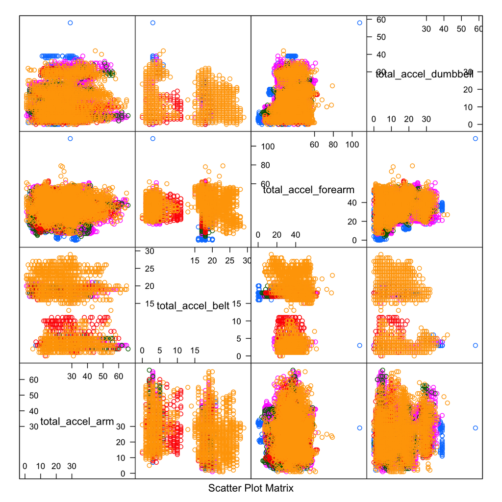

```r
featurePlot(x=alltraining[,c("total_accel_arm",
                             "total_accel_belt",
                             "total_accel_forearm",
                             "total_accel_dumbbell")],
            y = alltraining$classe,
            plot="pairs")
```

Unfortunately, this failed to deliver any obvious insights, even though I tried many combinations of explanatory variables. So I decided instead to trust a machine learning algorithm to find the explanatory correlations.

## Training and Cross-Validating

Since we have a lot of training data, we can extract a subset for cross validation as follows.

```r
trainIndex = createDataPartition(alltraining$classe, p = 0.60,list=FALSE)
training = alltraining[trainIndex,]
validating = alltraining[-trainIndex,]
```

Once we have training and cross-validating data sets, we remove the columns that are non-numeric or that contains many NaNs, as explained in the previous section.

```r
training.numeric = training[,nums & !has.nans]
training.numeric$classe = training$classe
validating.numeric = validating[,nums & !has.nans]
```

Now it’s time to train the model. With the caret package, it is easy to try any of a large number of machine learning algorithms. I happen to like decision trees for classification, and the C5.0 algorithm is the latest in a sequence of algorithms that build decision trees using the notion of entropy from information theory. Naturally, C5.0 was one of the first algorithms that I chose to consider. I also chose to center and scale the eplanatory variables, as suggested in class.

```r
modelFit <- train(classe ~ ., data=training.numeric,
                  preProcess=c("center", "scale"), method="C5.0")
modelFit
```

```
## C5.0
##
## 11776 samples
##    52 predictor
##     5 classes: 'A', 'B', 'C', 'D', 'E'
##
## Pre-processing: centered, scaled
## Resampling: Bootstrapped (25 reps)
##
## Summary of sample sizes: 11776, 11776, 11776, 11776, 11776, 11776, ...
##
## Resampling results across tuning parameters:
##
##   model  winnow  trials  Accuracy   Kappa      Accuracy SD  Kappa SD
##   rules  FALSE    1      0.9433983  0.9283807  0.004741057  0.006014406
##   rules  FALSE   10      0.9830065  0.9784913  0.001865581  0.002361072
##   rules  FALSE   20      0.9873506  0.9839905  0.002190817  0.002773937
##   rules   TRUE    1      0.9426183  0.9273919  0.004516855  0.005740627
##   rules   TRUE   10      0.9838782  0.9795946  0.002462903  0.003116433
##   rules   TRUE   20      0.9873494  0.9839897  0.001921740  0.002432243
##   tree   FALSE    1      0.9362989  0.9193931  0.004970690  0.006320481
##   tree   FALSE   10      0.9813448  0.9763914  0.002437208  0.003082884
##   tree   FALSE   20      0.9853149  0.9814165  0.001957678  0.002473988
##   tree    TRUE    1      0.9365111  0.9196659  0.005053972  0.006414072
##   tree    TRUE   10      0.9819735  0.9771858  0.002286614  0.002897648
##   tree    TRUE   20      0.9855267  0.9816830  0.001796890  0.002273828
##
## Accuracy was used to select the optimal model using  the largest value.
## The final values used for the model were trials = 20, model = rules
##  and winnow = FALSE.
```

The results of the fit look extremely promising, with more than 98% accuracy. I was concerned that the results may be overfitted, so I turned to cross-validation in order to estimate the out of sample error. To do that, I used the model to predict the classification of the observations that were saved for validation, and I compared the predictions to the actual values of classe in a “confusion matrix”.

```r
predictions <- predict(modelFit, newdata=validating.numeric)
confusionMatrix(predictions, validating$classe)
```

```
## Confusion Matrix and Statistics
##
##           Reference
## Prediction    A    B    C    D    E
##          A 2228    3    0    0    0
##          B    4 1513    3    1    0
##          C    0    1 1361    1    0
##          D    0    1    4 1282    1
##          E    0    0    0    2 1441
##
## Overall Statistics
##
##                Accuracy : 0.9973
##                  95% CI : (0.9959, 0.9983)
##     No Information Rate : 0.2845
##     P-Value [Acc > NIR] : < 2.2e-16
##
##                   Kappa : 0.9966
##  Mcnemar's Test P-Value : NA
##
## Statistics by Class:
##
##                      Class: A Class: B Class: C Class: D Class: E
## Sensitivity            0.9982   0.9967   0.9949   0.9969   0.9993
## Specificity            0.9995   0.9987   0.9997   0.9991   0.9997
## Pos Pred Value         0.9987   0.9947   0.9985   0.9953   0.9986
## Neg Pred Value         0.9993   0.9992   0.9989   0.9994   0.9998
## Prevalence             0.2845   0.1935   0.1744   0.1639   0.1838
## Detection Rate         0.2840   0.1928   0.1735   0.1634   0.1837
## Detection Prevalence   0.2843   0.1939   0.1737   0.1642   0.1839
## Balanced Accuracy      0.9988   0.9977   0.9973   0.9980   0.9995
```

As stated previously, C5.0 is an algorithm descended from a long line of algorithms that compute decisions trees based on entropy. One of the reasons I like this type of machine learning algorithms is that the resulting decision tree can be examined and sometimes understood, just as with linear regression. To explore this idea, I looked at the model with the following command.

```r
summary(modelFit$finalModel)
```

The output is extremely large, so I am placing it in the appendix. For now, I would like to draw attention to a few facts. First, one of the improvements of C5.0 over previous approaches (such as the IDx family of algorithms) is that C5.0 can learn rules (as in expert systems) as well as decision trees. With this particular dataset, C5.0 chose to create rules (or rather, the caret front-end chose rules after considering different models). While there are many rules, the following is representative:

[output not shown]

The second observation is that C5.0 considered 52 different explanatory variables. In the final model, 19 of these features are used more than 90% of the time, 31 of them more than 80% of the time, and 42 more than 60% of the time. It’s clear that there is no dominant feature that can predict the variable classe reliably, which reinforces what I discovered during exploratory analysis.

## Testing

The predicted classifications can be found as follows:

```r
testing.numeric = testing[,nums & !has.nans]
test.predictions <- predict(modelFit, newdata=testing.numeric)
```

There are 20 observations in the testing set, so this yields 20 predicted classifications. Given the high accuracy achieved during cross-validation, I expected that 19 or 20 of these predictions would prove correct. To test this, I uploaded the classifications to the assignment website, and I was happily surprised that all 20 predictions were correct. This confirmed the suspicion that the model is sufficiently accurate as-is, so there is no need to consider more complex models.

## Appendix: The Model Built by C5.0

Here is the full model that C5.0 found during training.

```r
summary(modelFit$finalModel)
```

```
##
## Call:
## C5.0.default(x = structure(c(-1.00861149372092,
##  -0.582919404981213, 0.901961107926621,
##  0.710363622390127, 0.183470537164766, -0.05602631975585
##
##
## C5.0 [Release 2.07 GPL Edition]      Thu Jun 18 08:23:43 2015
## -------------------------------
##
## Class specified by attribute `outcome'
##
## Read 11776 cases (53 attributes) from undefined.data
##
## -----  Trial 0:  -----
##
## Rules:
##
## Rule 0/1: (890, lift 3.5)
##  accel_dumbbell_x <= 0.987001
##  roll_forearm <= 0.5733259
##  pitch_forearm <= -1.165753
##  ->  class A  [0.999]
##
## Rule 0/2: (574, lift 3.5)
##  yaw_arm <= -1.598705
##  magnet_arm_z > 0.5182409
##  magnet_dumbbell_z <= 0.1597389
##  roll_forearm <= 0.7340601
##  ->  class A  [0.998]
##
## Rule 0/3: (494, lift 3.5)
##  roll_belt <= 0.9597436
##  yaw_arm <= -1.598705
##  magnet_arm_z > 0.5182409
##  accel_dumbbell_x <= 0.987001
##  roll_forearm <= 0.7340601
##  ->  class A  [0.998]
##
## Rule 0/4: (556, lift 3.5)
```

[output cut: 29508 more lines]

```
##   60.30% magnet_arm_y
##   56.48% pitch_dumbbell
##   55.69% gyros_forearm_z
##   54.62% accel_forearm_y
##   52.85% total_accel_arm
##   50.54% yaw_forearm
##   48.92% accel_arm_z
##   43.78% gyros_arm_z
##   41.68% accel_arm_y
##   39.98% accel_belt_y
##   32.00% accel_belt_x
##   30.18% total_accel_belt
##
##
## Time: 21.6 secs
```